# ANALYSIS AND VISUALIZATION

## Introduction

WeRateDogs is a twitter account that rate dogs. Here, we have used the appropriate data wrangling technique to gather, access, and clean the data in order to visualize certain outcomes from the data.

### Most Used Twitter Source

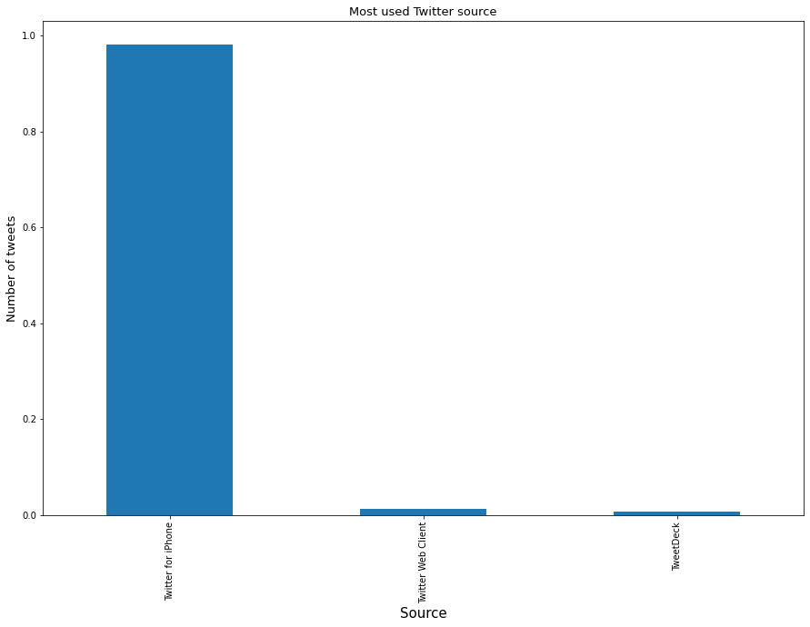

From the above bar-chart,three sources are used to access twitter which include Twitter for iphone, twitter for web-client and tweetdeck. Tweetdeck is the least used means to access the platform while Twitter for iphone is the most used method. From this, we can say that people make use of mobile phones to access twitter more than desktop because the value of twitter for iphone is more that twitter for web-client and tweetdeck combined.

### Most popular Dog names

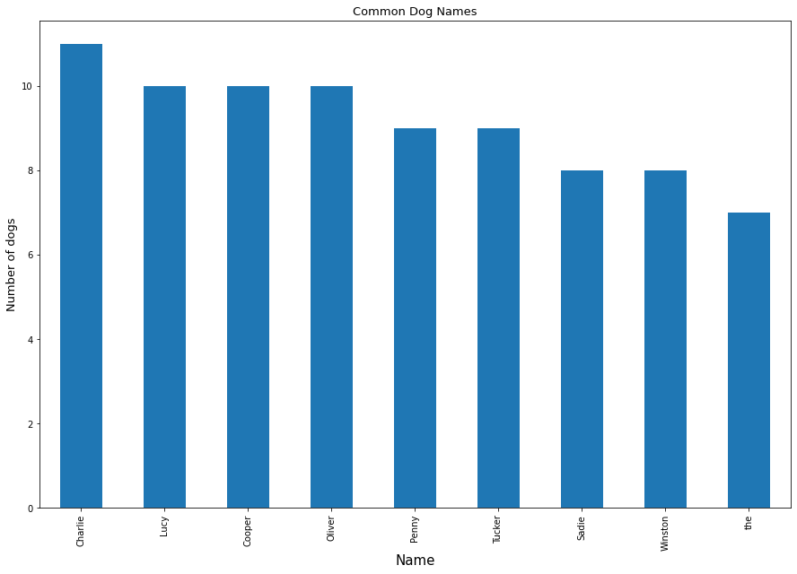

### Correlation Between Retweet and Favorite

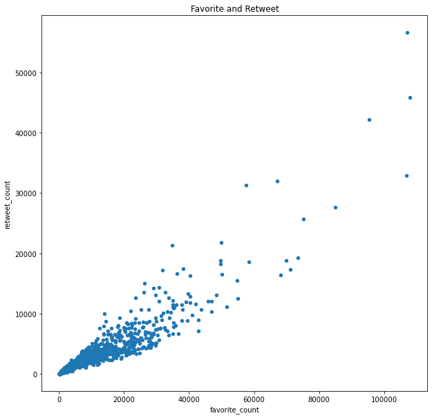

The abobe result shows the correlation between the retweet count and favorite count. There is a positive correlation betweet the number of retweet and number of favorite tweet.